# carrerfour_analysis

Bill

11/13/2020

# 1. Problem Definition

## 1.1 Defining the Question

As a Data analyst at Carrefour Kenya,I have been consulted to undertake a project that will inform the marketing department on the most relevant marketing strategies that will result in the highest no. of sales (total price including tax). My project will explore a recent marketing dataset provided by performing various unsupervised learning techniques and later providing recommendations based on my insights.

## 1.2 Specifying the Question

I am expected to reduce the dataset provided to a low dimensional dataset using the t-SNE algorithm or PCA, then perform analysis and provide insights gained from my analysis.

## 1.4 Understanding the Context

Carrefour, one of the largest hypermarket chains in the world was introduced to the Middle East and North Africa (MENA) market in 1995 by Majid Al Futtaim, the leading shopping mall, retail and leisure pioneer across MENA.

Carrefour has become the most dynamic, fast-moving and exciting hypermarket chain in the region and shared its growth with more than 38,000 employees from more than 70 nationalities in 15 countries, providing shoppers with variety and value-for-money.

Carrefour ensures customer satisfaction and everyday convenience while offering unbeatable value for money with a vast array of more than 100,000 products, shoppers can purchase items for their every need, whether home electronics or fresh fruits from around the world, to locally produced items.

Carrefour opened its first outlet in Kenya in 2016, and currently operates over 250 hypermarkets, supermarkets, and online stores in 15 countries across the region, with plans to extend into 38 countries in the Middle East, Central Asia, Africa and Russia.

Carrefour always strive to provide the best quality and most diverse selection of household goods available in Kenya. Our value packs and combination discount offers means that we can offer these products at even lower costs, keeping your household essentials at unbeatable prices.

## 1.5 Experimental Design taken

```r
## Loading packages that we will use during our analysis
library("dplyr")
library("purrr")
library('tidyverse')
library('magrittr')
```

```r
library('corrplot')
library('caret')
library('skimr')
library(readr)
```

```r
Supermarket_Dataset<- read_csv("datasets/Supermarket_Dataset_1 - Sales Data.csv")
## previewing first 6 rows
head(Supermarket_Dataset)
```

```
## # A tibble: 6 x 16
##   `Invoice ID` Branch `Customer type` Gender `Product line` `Unit price`
##   <chr>        <chr>  <chr>           <chr>  <chr>                 <dbl>
## 1 750-67-8428  A      Member          Female Health and be~         74.7
## 2 226-31-3081  C      Normal          Female Electronic ac~         15.3
## 3 631-41-3108  A      Normal          Male   Home and life~         46.3
## 4 123-19-1176  A      Member          Male   Health and be~         58.2
## 5 373-73-7910  A      Normal          Male   Sports and tr~         86.3
## 6 699-14-3026  C      Normal          Male   Electronic ac~         85.4
## # ... with 10 more variables: Quantity <dbl>, Tax <dbl>, Date <chr>,
## #   Time <time>, Payment <chr>, cogs <dbl>, `gross margin percentage` <dbl>,
## #   `gross income` <dbl>, Rating <dbl>, Total <dbl>
```

```r
##previewing the last 6 rows of the dataset
tail(Supermarket_Dataset)
```

```
## # A tibble: 6 x 16
##   `Invoice ID` Branch `Customer type` Gender `Product line` `Unit price`
##   <chr>        <chr>  <chr>           <chr>  <chr>                 <dbl>
## 1 652-49-6720  C      Member          Female Electronic ac~         61.0
## 2 233-67-5758  C      Normal          Male   Health and be~         40.4
## 3 303-96-2227  B      Normal          Female Home and life~         97.4
## 4 727-02-1313  A      Member          Male   Food and beve~         31.8
## 5 347-56-2442  A      Normal          Male   Home and life~         65.8
## 6 849-09-3807  A      Member          Female Fashion acces~         88.3
## # ... with 10 more variables: Quantity <dbl>, Tax <dbl>, Date <chr>,
## #   Time <time>, Payment <chr>, cogs <dbl>, `gross margin percentage` <dbl>,
## #   `gross income` <dbl>, Rating <dbl>, Total <dbl>
```

```r
## Previewing the shape of our dataset
dim(Supermarket_Dataset)
```

```
## [1] 1000   16
```

```r
### we have 1000  rows and 16 columns!!!BAM!!

#checking the datatypes on the columns
sapply(Supermarket_Dataset, class)
```

```
## $`Invoice ID`
## [1] "character"
##
## $Branch
## [1] "character"
##
## $`Customer type`
## [1] "character"
##
## $Gender
## [1] "character"
##
## $`Product line`
## [1] "character"
##
## $`Unit price`
## [1] "numeric"
##
## $Quantity
## [1] "numeric"
##
## $Tax
## [1] "numeric"
##
## $Date
## [1] "character"
##
## $Time
## [1] "hms"      "difftime"
##
## $Payment
## [1] "character"
##
## $cogs
## [1] "numeric"
##
## $`gross margin percentage`
## [1] "numeric"
##
## $`gross income`
## [1] "numeric"
##
## $Rating
## [1] "numeric"
##
## $Total
## [1] "numeric"
```

```r
### Our dataset is comprised of numeric and character data types and one datetime
##checking for structure is using the str()
str(Supermarket_Dataset)
```

```
## tibble [1,000 x 16] (S3: spec_tbl_df/tbl_df/tbl/data.frame)
##  $ Invoice ID             : chr [1:1000] "750-67-8428" "226-31-3081" "631-41-3108" "123-19-1176" ...
##  $ Branch                 : chr [1:1000] "A" "C" "A" "A" ...
##  $ Customer type          : chr [1:1000] "Member" "Normal" "Normal" "Member" ...
##  $ Gender                 : chr [1:1000] "Female" "Female" "Male" "Male" ...
##  $ Product line           : chr [1:1000] "Health and beauty" "Electronic accessories" "Home and lifestyle" "Health and beauty" ...
##  $ Unit price             : num [1:1000] 74.7 15.3 46.3 58.2 86.3 ...
##  $ Quantity               : num [1:1000] 7 5 7 8 7 7 6 10 2 3 ...
##  $ Tax                    : num [1:1000] 26.14 3.82 16.22 23.29 30.21 ...
##  $ Date                   : chr [1:1000] "1/5/2019" "3/8/2019" "3/3/2019" "1/27/2019" ...
##  $ Time                   : 'hms' num [1:1000] 13:08:00 10:29:00 13:23:00 20:33:00 ...
##   ..- attr(*, "units")= chr "secs"
##  $ Payment                : chr [1:1000] "Ewallet" "Cash" "Credit card" "Ewallet" ...
##  $ cogs                   : num [1:1000] 522.8 76.4 324.3 465.8 604.2 ...
##  $ gross margin percentage: num [1:1000] 4.76 4.76 4.76 4.76 4.76 ...
##  $ gross income           : num [1:1000] 26.14 3.82 16.22 23.29 30.21 ...
##  $ Rating                 : num [1:1000] 9.1 9.6 7.4 8.4 5.3 4.1 5.8 8 7.2 5.9 ...
##  $ Total                  : num [1:1000] 549 80.2 340.5 489 634.4 ...
##  - attr(*, "spec")=
##   .. cols(
##   ..   `Invoice ID` = col_character(),
##   ..   Branch = col_character(),
##   ..   `Customer type` = col_character(),
##   ..   Gender = col_character(),
##   ..   `Product line` = col_character(),
##   ..   `Unit price` = col_double(),
##   ..   Quantity = col_double(),
##   ..   Tax = col_double(),
##   ..   Date = col_character(),
##   ..   Time = col_time(format = ""),
##   ..   Payment = col_character(),
##   ..   cogs = col_double(),
##   ..   `gross margin percentage` = col_double(),
##   ..   `gross income` = col_double(),
##   ..   Rating = col_double(),
##   ..   Total = col_double()
##   .. )
```

```r
## We then a statistical summary of our dataset

summary(Supermarket_Dataset)
```

```
##   Invoice ID           Branch          Customer type         Gender
##  Length:1000        Length:1000        Length:1000        Length:1000
##  Class :character   Class :character   Class :character   Class :character
##  Mode  :character   Mode  :character   Mode  :character   Mode  :character
##
##
##
##  Product line         Unit price       Quantity          Tax
##  Length:1000        Min.   :10.08   Min.   : 1.00   Min.   : 0.5085
##  Class :character   1st Qu.:32.88   1st Qu.: 3.00   1st Qu.: 5.9249
##  Mode  :character   Median :55.23   Median : 5.00   Median :12.0880
##                     Mean   :55.67   Mean   : 5.51   Mean   :15.3794
##                     3rd Qu.:77.94   3rd Qu.: 8.00   3rd Qu.:22.4453
##                     Max.   :99.96   Max.   :10.00   Max.   :49.6500
##      Date               Time            Payment               cogs
##  Length:1000        Length:1000       Length:1000        Min.   : 10.17
##  Class :character   Class1:hms        Class :character   1st Qu.:118.50
##  Mode  :character   Class2:difftime   Mode  :character   Median :241.76
##                     Mode  :numeric                       Mean   :307.59
##                                                          3rd Qu.:448.90
##                                                          Max.   :993.00
##  gross margin percentage  gross income         Rating           Total
##  Min.   :4.762           Min.   : 0.5085   Min.   : 4.000   Min.   :  10.68
##  1st Qu.:4.762           1st Qu.: 5.9249   1st Qu.: 5.500   1st Qu.: 124.42
##  Median :4.762           Median :12.0880   Median : 7.000   Median : 253.85
##  Mean   :4.762           Mean   :15.3794   Mean   : 6.973   Mean   : 322.97
##  3rd Qu.:4.762           3rd Qu.:22.4453   3rd Qu.: 8.500   3rd Qu.: 471.35
##  Max.   :4.762           Max.   :49.6500   Max.   :10.000   Max.   :1042.65
```

## Appropriateness of Our Dataset

The dataset contains 1000 rows and 16 columns which is sufficient enough for perfoming our analysis..We have 16 features which we will be forced to reduce them to a small number using PCA and t-SNE

# 4. Perform Data Cleaning

## To ensure uniformity, I will lowercase all the columns

```r
names(Supermarket_Dataset)<- tolower(names(Supermarket_Dataset))
head(Supermarket_Dataset)
```

```
## # A tibble: 6 x 16
##   `invoice id` branch `customer type` gender `product line` `unit price`
##   <chr>        <chr>  <chr>           <chr>  <chr>                 <dbl>
## 1 750-67-8428  A      Member          Female Health and be~         74.7
## 2 226-31-3081  C      Normal          Female Electronic ac~         15.3
## 3 631-41-3108  A      Normal          Male   Home and life~         46.3
## 4 123-19-1176  A      Member          Male   Health and be~         58.2
## 5 373-73-7910  A      Normal          Male   Sports and tr~         86.3
## 6 699-14-3026  C      Normal          Male   Electronic ac~         85.4
## # ... with 10 more variables: quantity <dbl>, tax <dbl>, date <chr>,
## #   time <time>, payment <chr>, cogs <dbl>, `gross margin percentage` <dbl>,
## #   `gross income` <dbl>, rating <dbl>, total <dbl>
```

NEXT I’m going to checking for missing values in our dataset,,Missing values may affect the perfomance of our model, so we will find a way to deal with them

```r
##Checking for missing values in each row
colSums(is.na(Supermarket_Dataset))
```

```
##              invoice id                  branch           customer type
##                       0                       0                       0
##                  gender            product line              unit price
##                       0                       0                       0
##                quantity                     tax                    date
##                       0                       0                       0
##                    time                 payment                    cogs
##                       0                       0                       0
## gross margin percentage            gross income                  rating
##                       0                       0                       0
##                   total
##                       0
```

There are no missing values in our dataset…The Company did a pretty good job in data collection and data entry

So far so good!!! Lets now check for duplicates in our dataset,,,This may arise due to mistakes incurred during data collection and data entry.. R gives us better ways of dealing and checking duplicates,,,Lets explore them below

```r
anyDuplicated(Supermarket_Dataset)
```

```
## [1] 0
```

We also dont have duplicates in our dataset,,,,Nice

Next we are going to check for outliers in our numerical data,,This can be very extremely high or low values in our dataset that needs investigation…We only check for outliers in our numerical columns

```r
## obtaining numerical columns
numeric_columns <- unlist(lapply(Supermarket_Dataset, is.numeric))

numeric_columns
```

```
##              invoice id                  branch           customer type
##                   FALSE                   FALSE                   FALSE
##                  gender            product line              unit price
##                   FALSE                   FALSE                    TRUE
##                quantity                     tax                    date
##                    TRUE                    TRUE                   FALSE
##                    time                 payment                    cogs
##                   FALSE                   FALSE                    TRUE
## gross margin percentage            gross income                  rating
##                    TRUE                    TRUE                    TRUE
##                   total
##                    TRUE
```

```r
## I will put the numerical columns in a dataframe

columns_numeric <- Supermarket_Dataset[ , numeric_columns]

head(columns_numeric)
```

```
## # A tibble: 6 x 8
##   `unit price` quantity   tax  cogs `gross margin p~ `gross income` rating total
##          <dbl>    <dbl> <dbl> <dbl>            <dbl>          <dbl>  <dbl> <dbl>
## 1         74.7        7 26.1  523.              4.76          26.1     9.1 549.
## 2         15.3        5  3.82  76.4             4.76           3.82    9.6  80.2
## 3         46.3        7 16.2  324.              4.76          16.2     7.4 341.
## 4         58.2        8 23.3  466.              4.76          23.3     8.4 489.
## 5         86.3        7 30.2  604.              4.76          30.2     5.3 634.
## 6         85.4        7 29.9  598.              4.76          29.9     4.1 628.
```

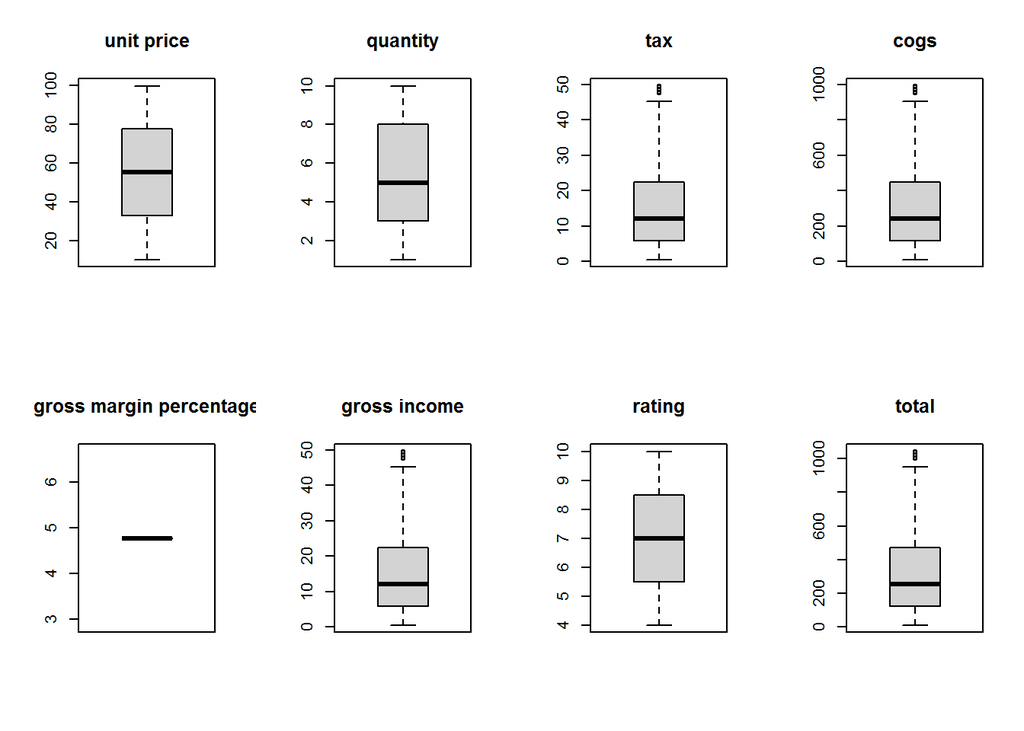

```r
# using a for lop, I will output boxplots of numerical columns..This will help me to identify the outliers

par ( mfrow= c (  2, 4 ))
for (i in 1 : length (columns_numeric)) {
boxplot (columns_numeric[,i], main= names (columns_numeric[i]), type= "l" )
}
```

From the boxplots, outliers are present in the tax, cogs, gross income and totals columns….Dropping this outliers may affect our analysis as the extreme values might be genuine records..So I will not drop any outliers

Next We will check anomalies and inconsistenicies in our dataframe….Since we have categorical column, we will need to convert them to factors

```r
lengths(lapply(Supermarket_Dataset, unique))
```

```
##              invoice id                  branch           customer type
##                    1000                       3                       2
##                  gender            product line              unit price
##                       2                       6                     943
##                quantity                     tax                    date
##                      10                     990                      89
##                    time                 payment                    cogs
##                     506                       3                     990
## gross margin percentage            gross income                  rating
##                       1                     990                      61
##                   total
##                     990
```

Our values seems fine……There is no need for an alarm

## Univariate Analysis

Here we analyse single variables by checking the measures of central tendency and measures of dispersion… Lets begin with measures of central tendency

```r
## Getting the mean of all numerical columns
colMeans(columns_numeric)
```

```
##              unit price                quantity                     tax
##               55.672130                5.510000               15.379369
##                    cogs gross margin percentage            gross income
##              307.587380                4.761905               15.379369
##                  rating                   total
##                6.972700              322.966749
```

##Median

```r
apply(columns_numeric,2,median)
```

```
##              unit price                quantity                     tax
##               55.230000                5.000000               12.088000
##                    cogs gross margin percentage            gross income
##              241.760000                4.761905               12.088000
##                  rating                   total
##                7.000000              253.848000
```

### Mode

```r
getmode <- function(v) {
   uniqv <- unique(v)
   uniqv[which.max(tabulate(match(v, uniqv)))]
}

##getting the mode of all our numerical columns
apply(columns_numeric,2,getmode)
```

```
##              unit price                quantity                     tax
##               83.770000               10.000000               39.480000
##                    cogs gross margin percentage            gross income
##              789.600000                4.761905               39.480000
##                  rating                   total
##                6.000000              829.080000
```

##Measures of Dispersion

```r
## we will do this by finding the statistical summary
summary(Supermarket_Dataset)
```

```
##   invoice id           branch          customer type         gender
##  Length:1000        Length:1000        Length:1000        Length:1000
##  Class :character   Class :character   Class :character   Class :character
##  Mode  :character   Mode  :character   Mode  :character   Mode  :character
##
##
##
##  product line         unit price       quantity          tax
##  Length:1000        Min.   :10.08   Min.   : 1.00   Min.   : 0.5085
##  Class :character   1st Qu.:32.88   1st Qu.: 3.00   1st Qu.: 5.9249
##  Mode  :character   Median :55.23   Median : 5.00   Median :12.0880
##                     Mean   :55.67   Mean   : 5.51   Mean   :15.3794
##                     3rd Qu.:77.94   3rd Qu.: 8.00   3rd Qu.:22.4453
##                     Max.   :99.96   Max.   :10.00   Max.   :49.6500
##      date               time            payment               cogs
##  Length:1000        Length:1000       Length:1000        Min.   : 10.17
##  Class :character   Class1:hms        Class :character   1st Qu.:118.50
##  Mode  :character   Class2:difftime   Mode  :character   Median :241.76
##                     Mode  :numeric                       Mean   :307.59
##                                                          3rd Qu.:448.90
##                                                          Max.   :993.00
##  gross margin percentage  gross income         rating           total
##  Min.   :4.762           Min.   : 0.5085   Min.   : 4.000   Min.   :  10.68
##  1st Qu.:4.762           1st Qu.: 5.9249   1st Qu.: 5.500   1st Qu.: 124.42
##  Median :4.762           Median :12.0880   Median : 7.000   Median : 253.85
##  Mean   :4.762           Mean   :15.3794   Mean   : 6.973   Mean   : 322.97
##  3rd Qu.:4.762           3rd Qu.:22.4453   3rd Qu.: 8.500   3rd Qu.: 471.35
##  Max.   :4.762           Max.   :49.6500   Max.   :10.000   Max.   :1042.65
```

## Standard Deviation

```r
apply(columns_numeric,2,sd)
```

```
##              unit price                quantity                     tax
##               26.494628                2.923431               11.708825
##                    cogs gross margin percentage            gross income
##              234.176510                0.000000               11.708825
##                  rating                   total
##                1.718580              245.885335
```

## Variance

```r
sapply(columns_numeric, var)
```

```
##              unit price                quantity                     tax
##              701.965331                8.546446              137.096594
##                    cogs gross margin percentage            gross income
##            54838.637658                0.000000              137.096594
##                  rating                   total
##                2.953518            60459.598018
```

## Bivariate and Multivariate Analysis

I Will check for the corelation of all our numerical columns

##Correlation matrix of all numerical columns

```r
corr <- cor(columns_numeric, method = "pearson")
round(corr, 2)
```

```
##                         unit price quantity   tax  cogs gross margin percentage
## unit price                    1.00     0.01  0.63  0.63                      NA
## quantity                      0.01     1.00  0.71  0.71                      NA
## tax                           0.63     0.71  1.00  1.00                      NA
## cogs                          0.63     0.71  1.00  1.00                      NA
## gross margin percentage         NA       NA    NA    NA                       1
## gross income                  0.63     0.71  1.00  1.00                      NA
## rating                       -0.01    -0.02 -0.04 -0.04                      NA
## total                         0.63     0.71  1.00  1.00                      NA
##                         gross income rating total
## unit price                      0.63  -0.01  0.63
## quantity                        0.71  -0.02  0.71
## tax                             1.00  -0.04  1.00
## cogs                            1.00  -0.04  1.00
## gross margin percentage           NA     NA    NA
## gross income                    1.00  -0.04  1.00
## rating                         -0.04   1.00 -0.04
## total                           1.00  -0.04  1.00
```

## Observations

Unit price has a strong positive correlation with total of 0.63 quantity has a strong positive correlation with total of 0.71  
tax, gross income and cogs are strongly correlated to total with a correlation of 1